# Data Camp Insights

davegoblue

April 26, 2017

## Background and Overview

DataCamp offer interactive courses related to R Programming. While some is review, it is helpful to see other perspectives on material. As well, DataCamp has some interesting materials on packages that I want to learn better (ggplot2, dplyr, ggvis, etc.). This document summarizes a few key insights from:

This document is currently split between _v003 and _v003_a and _v003_b due to the need to keep the number of DLL that it opens below the hard-coded maximum. This introductory section needs to be re-written, and the contents consolidated, at a future date.

- R Programming (Introductory R, Intermediate R, Writing Functions in R, Object Oriented Programming in R, Introduction to Tidyverse)
- Importing and Cleaning Data (Cleaning Data in R, Importing Data in to R)
- Data Manipulation (dplyr, data.table, xts/zoo, dplyr joins, cases for EDA/Time Series/Pitch Data)
- Data Visualization (base, ggplot2 parts I/II/III, ggvis, geospatial)
- Statistics (8 refresher modules)
- Machine Learning (3 modules + 1 text mining case)
- R Studio (2 parts) and R Markdown (1 module)

The original DataCamp_Insights_v001 and DataCamp_Insights_v002 documents have been split for this document:

- This DataCamp_Insights_v003 document contains evolving sections on R Programming, Machine Learning, and RStudio / R Markdown
- Importing and Cleaning Data components have been moved to DataCamp_ImportClean_v002
- Data Manipulation components have been moved to DataCamp_DataManipulation_v002
- Visualization components have been moved to DataCamp_Visualization_v002
- Statistics components have been moved to DataCamp_Statistics_v002

### *Spatial Statistics in R*

Chapter 1 - Introduction

Problems in spatial statistics:

- Epidemics, susceptibility, locations, etc.
- Divisions of a lager area - healt disricts, counties, etc.
- Geostatistical data is the availability of data that has a spatial component
- At school we were taught to make the most of a piece of graph paper by scaling our data to fit the page
  - R will usually follow this advice by making a plot fill the graphics window
- With spatial data, this can cause misleading distortion that changes the distance and direction between pairs of points
  - The data in the previous exercise was created in a tall, skinny rectangle, and it should always be shown as a tall, skinny rectangle
  - If R stretches this to fill a wide graphics window then it is misrepresenting the relationship between events in the up-down and left-right directions
- So spatial plots should have scales so that one unit in the X axis is the same size as one unit on the Y axis
  - Circles will appear as circles and not ellipses, and squares will appear square
  - The ratio of the Y axis scale to the X axis scale is called the aspect ratio of the plot
  - Spatial data should always be presented with an aspect ratio of 1:1

Simulation and testing with spatstat:

- A “point” is defined to be any specific (x, y) location on the 2D plane
- An “event” is a key data point; in the literature, a point is just a location while an event is an observation or a specific point of interest
- The “window” is the defined study area, and events outside the window are unobserved
- A “spatial point pattern” is a set of events inside a defined window
- A “spatial point process” is a stochastic process (RNG) for events inside a defined window
- The spatstat library stores spatial objects inside the ppp library
  - Coordinates, window, marks, etc.
  - Defaults to a unit square for the window
  - Can plot(), print(), summary(), etc.
- The most basic type of spatial plot is “complete spatial randomness” (csr), where no part of the window differs from the others
  - In the quadrat test, the window is sub-divided in to squares, and counts are taken within each of the squares
  - The expected distribution would be the Poisson distribution, and the assessment of fit can be made using Chi-squared for counts by bucket
  - Quadrat count tests are implemented using quadrat.test(), which takes a planar point pattern, ppp() object
- A Poisson point process creates events according to a Poisson distribution with an intensity parameter specifying the expected events per unit area
  - The total number of events generated is a single number from a Poisson distribution, so multiple realisations of the same process can easily have different numbers of events

Further testing:

- The quadrat test depends on selecting the right sub-window size, otherwise the test can lose power due to homogeneity
- One alternative test is the “nearest neighbors” test - find the “nearest neighbor” for each event, calculate the distance, and plot the distribution
  - Can compare the ecdf with theoretical, accounting for edge-effect adjustments to theoretical, since events near the edge are deprived of potential close neighbors outside the window
- Another alternative test is the Ripley’s K Function
  - Count the number of events within a circle of diameter d from a specificed event
  - Plot the resulting function and compare with theoretical (~ pi * d**2)
  - Can calculate p-values based on comparisons to random simulation
  - If the observed data are greater than random CI at any specific value for d, that suggests clustering at around that distance
- Spatial statistics frequently uses Monte Carlo simulation to calculate CI and evaluate hypothesis tests

Example code includes:

```r
library(dplyr)
```

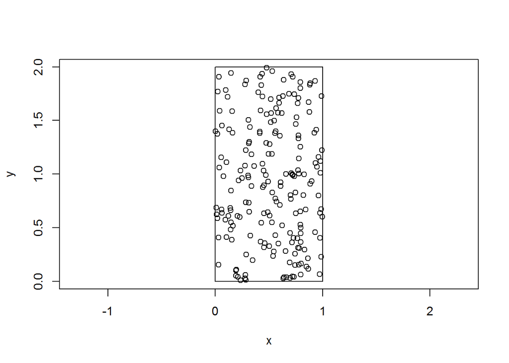

```r
library(ggplot2)

# The number of points to create
n <- 200

# Set the range
xmin <- 0
xmax <- 1
ymin <- 0
ymax <- 2

# Sample from a Uniform distribution
x <- runif(n, xmin, xmax)
y <- runif(n, ymin, ymax)


# The ratio of the Y axis scale to the X axis scale is called the aspect ratio of the plot. Spatial data should always be presented with an aspect ratio of 1:1.
# See pre-defined variables
# ls.str()

# Plot points and a rectangle

mapxy <- function(a = NA){
  plot(x, y, asp = a)
  rect(xmin, ymin, xmax, ymax)
}

mapxy(1)
```

```r
# How do we create a uniform density point pattern in a circle?
# We might first try selecting radius and angle uniformly.  But that produces a "cluster" at small distances
# Instead we sample the radius from a non-uniform distribution that scales linearly with distance, so we have fewer points at small radii and more at large radii
# This exercise uses spatstat's disc() function, that creates a circular window.

# Load the spatstat package
library(spatstat)
```

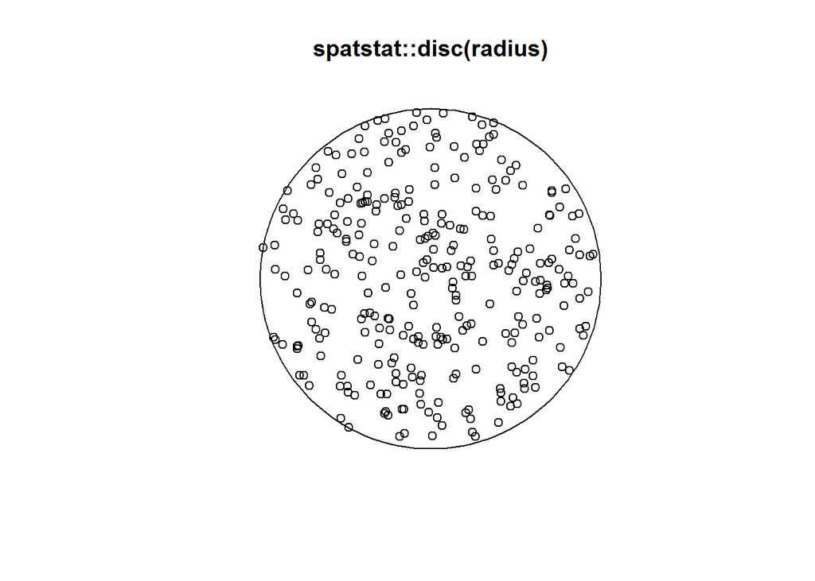

```r
# Create this many points, in a circle of this radius
n_points <- 300
radius <- 10

# Generate uniform random numbers up to radius-squared
r_squared <- runif(n_points, 0, radius**2)
angle <- runif(n_points, 0, 2*pi)

# Take the square root of the values to get a uniform spatial distribution
x <- sqrt(r_squared) * cos(angle)
y <- sqrt(r_squared) * sin(angle)

plot(spatstat::disc(radius))
points(x, y)
```

```r
# Some variables have been pre-defined
# ls.str()

# Set coordinates and window
ppxy <- ppp(x = x, y = y, window = disc(radius))

# Test the point pattern
qt <- quadrat.test(ppxy)
```

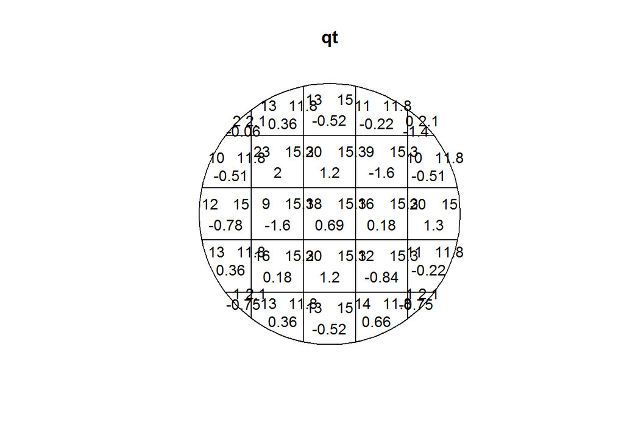

```r
# Inspect the results
plot(qt)
```

```r
print(qt)
```

```
##
##  Chi-squared test of CSR using quadrat counts
##  Pearson X2 statistic
##
## data:  ppxy
## X2 = 20.696, df = 24, p-value = 0.6868
## alternative hypothesis: two.sided
##
## Quadrats: 25 tiles (irregular windows)
```

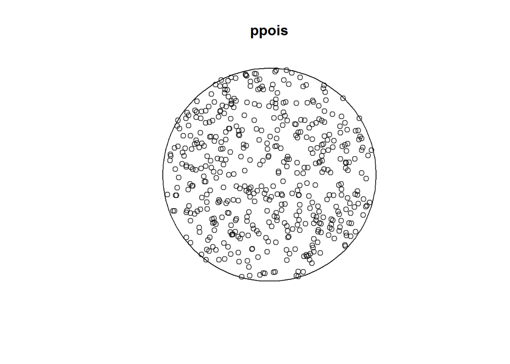

```r
# In the previous exercise you used a set of 300 events scattered uniformly within a circle
# If you repeated the generation of the events again you will still have 300 of them, but in different locations
# The dataset of exactly 300 points is from a Poisson point process conditioned on the total being 300
# The spatstat package can generate Poisson spatial processes with the rpoispp() function given an intensity and a window, that are not conditioned on the total
# Just as the random number generator functions in R start with an "r", most of the random point-pattern functions in spatstat start with an "r".
# The area() function of spatstat will compute the area of a window such as a disc

# Create a disc of radius 10
disc10 <- disc(10)

# Compute the rate as count divided by area
lambda <- 500 / area(disc10)

# Create a point pattern object
ppois <- rpoispp(lambda = lambda, win = disc10)

# Plot the Poisson point pattern
plot(ppois)
```

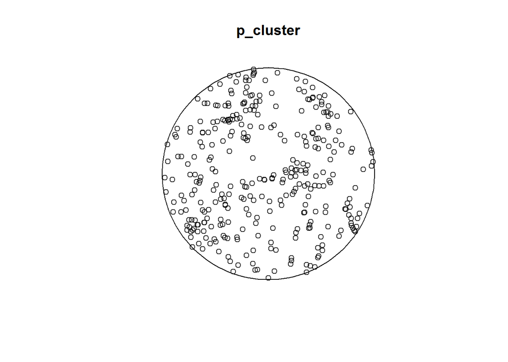

```r
# The spatstat package also has functions for generating point patterns from other process modelsparameters.
# These generally fall into one of two classes: clustered processes, where points occur together more than under a uniform Poisson process,
# and regular (aka inhibitory) processes where points are more spaced apart than under a uniform intensity Poisson process
# Some process models can generate patterns on a continuum from clustered through uniform to regular depending on their parameters

# The quadrat.test() function can test against clustered or regular alternative hypotheses
# By default it tests against either of those, but this can be changed with the alternative parameter to create a one-sided test.

# A Thomas process is a clustered pattern where a number of "parent" points, uniformly distributed, create a number of "child" points in their neighborhood
# The child points themselves form the pattern. This is an attractive point pattern, and makes sense for modelling things like trees, since new trees will grow near the original tree
# Random Thomas point patterns can be generated using rThomas()
# This takes three numbers that determine the intensity and clustering of the points, and a window object.

# Conversely the points of a Strauss process cause a lowering in the probability of finding another point nearby
# The parameters of a Strauss process can be such that it is a "hard-core" process, where no two points can be closer than a set threshold
# Creating points from this process involves some clever simulation algorithms
# This is a repulsive point pattern, and makes sense for modelling things like territorial animals, since the other animals of that species will avoid the territory of a given animal
# Random Strauss point patterns can be generated using rStrauss()
# This takes three numbers that determine the intensity and "territory" of the points, and a window object
# Points generated by a Strauss process are sometimes called regularly spaced.

# Create a disc of radius 10
disc10 <- disc(10)

# Generate clustered points from a Thomas process
set.seed(123)
p_cluster <- rThomas(kappa = 0.35, scale = 1, mu = 3, win = disc10)
plot(p_cluster)
```

```r
# Run a quadrat test
quadrat.test(p_cluster, alternative = "clustered")
```

```
##
##  Chi-squared test of CSR using quadrat counts
##  Pearson X2 statistic
##
## data:  p_cluster
## X2 = 53.387, df = 24, p-value = 0.0005142
## alternative hypothesis: clustered
##
## Quadrats: 25 tiles (irregular windows)
```

```r
# Regular points from a Strauss process
set.seed(123)
p_regular <- rStrauss(beta = 2.9, gamma = 0.025, R = .5, W = disc10)
```

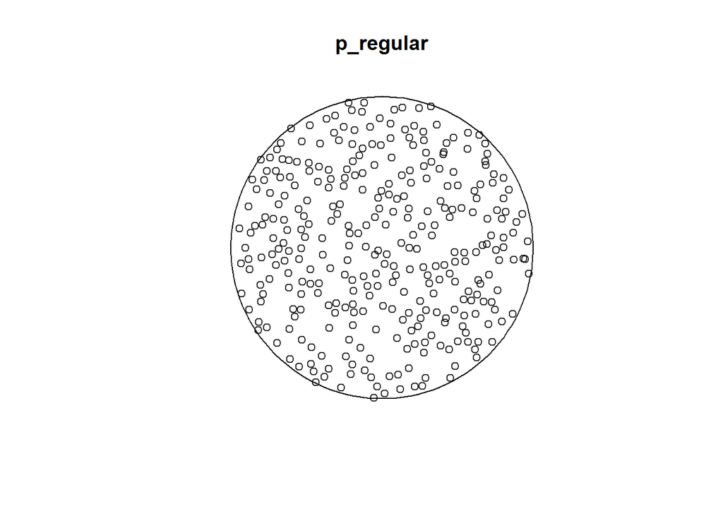

```r
plot(p_regular)
```

```r
# Run a quadrat test
quadrat.test(p_regular, alternative = "regular")
```

```
##
##  Chi-squared test of CSR using quadrat counts
##  Pearson X2 statistic
##
## data:  p_regular
## X2 = 8.57, df = 24, p-value = 0.001619
## alternative hypothesis: regular
##
## Quadrats: 25 tiles (irregular windows)
```

```r
# Another way of assessing clustering and regularity is to consider each point, and how it relates to the other points
# One simple measure is the distribution of the distances from each point to its nearest neighbor
# The nndist() function in spatstat takes a point pattern and for each point returns the distance to its nearest neighbor

# Instead of working with the nearest-neighbor density, as seen in the histogram, it can be easier to work with the cumulative distribution function, G(r)
# This is the probability of a point having a nearest neighbour within a distance r
# For a uniform Poisson process, G can be computed theoretically, and is G(r) = 1 - exp( - lambda * pi * r ^ 2)
# You can compute G empirically from your data using Gest() and so compare with the theoretical value.

# Events near the edge of the window might have had a nearest neighbor outside the window, and so unobserved
# This will make the distance to its observed nearest neighbor larger than expected, biasing the estimate of G
# There are several methods for correcting this bias

# Plotting the output from Gest shows the theoretical cumulative distribution and several estimates of the cumulative distribution using different edge corrections
# Often these edge corrections are almost indistinguishable, and the lines overlap
# The plot can be used as a quick exploratory test of complete spatial randomness

# Two ppp objects, p_poisson, and p_regular are defined for you
# Point patterns are pre-defined
p_poisson <- ppois
p_poisson
```

```
## Planar point pattern: 481 points
## window: polygonal boundary
## enclosing rectangle: [-10, 10] x [-10, 10] units
```

```r
p_regular
```

```
## Planar point pattern: 325 points
## window: polygonal boundary
## enclosing rectangle: [-10, 10] x [-10, 10] units
```

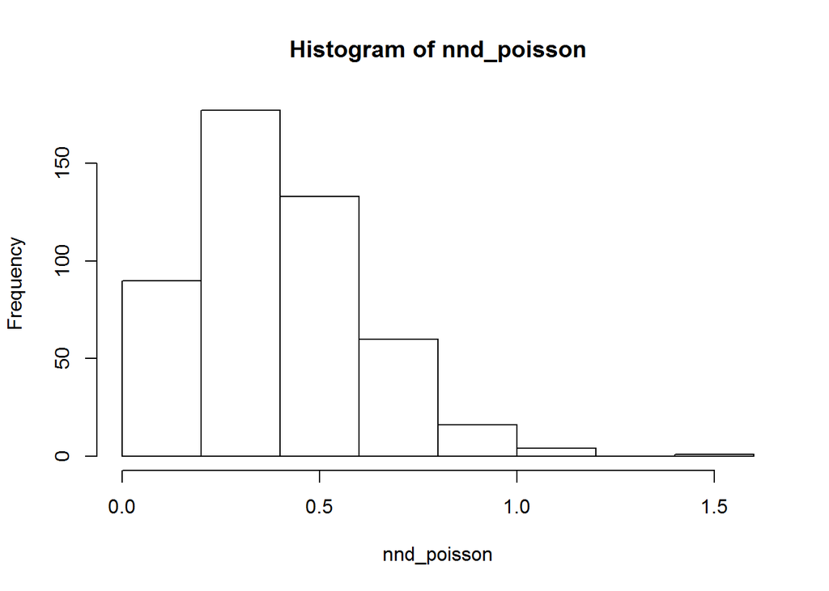

```r
# Calc nearest-neighbor distances for Poisson point data
nnd_poisson <- nndist(p_poisson)

# Draw a histogram of nearest-neighbor distances
hist(nnd_poisson)
```

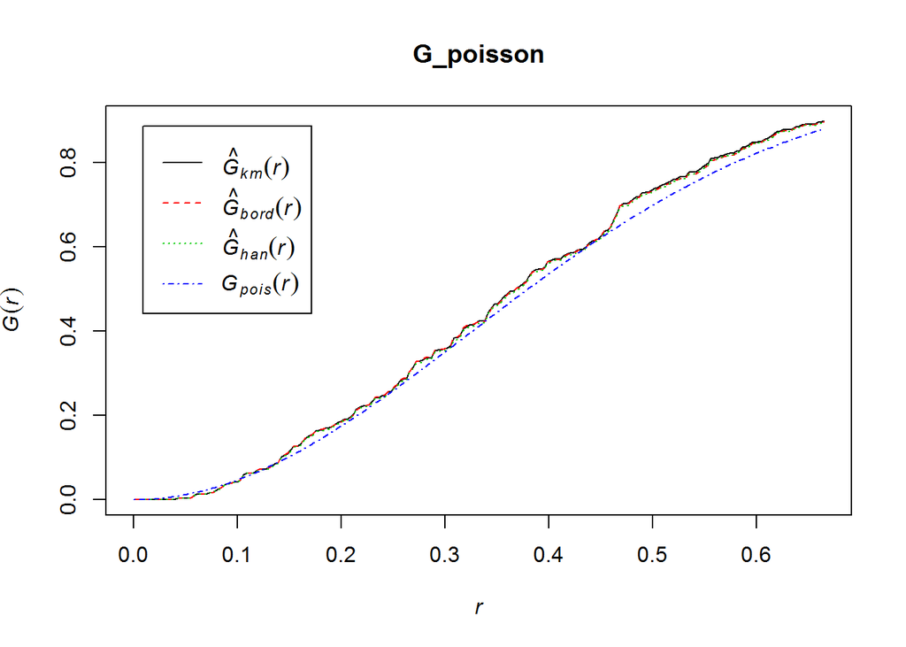

```r
# Estimate G(r)
G_poisson <- Gest(p_poisson)

# Plot G(r) vs. r
plot(G_poisson)
```

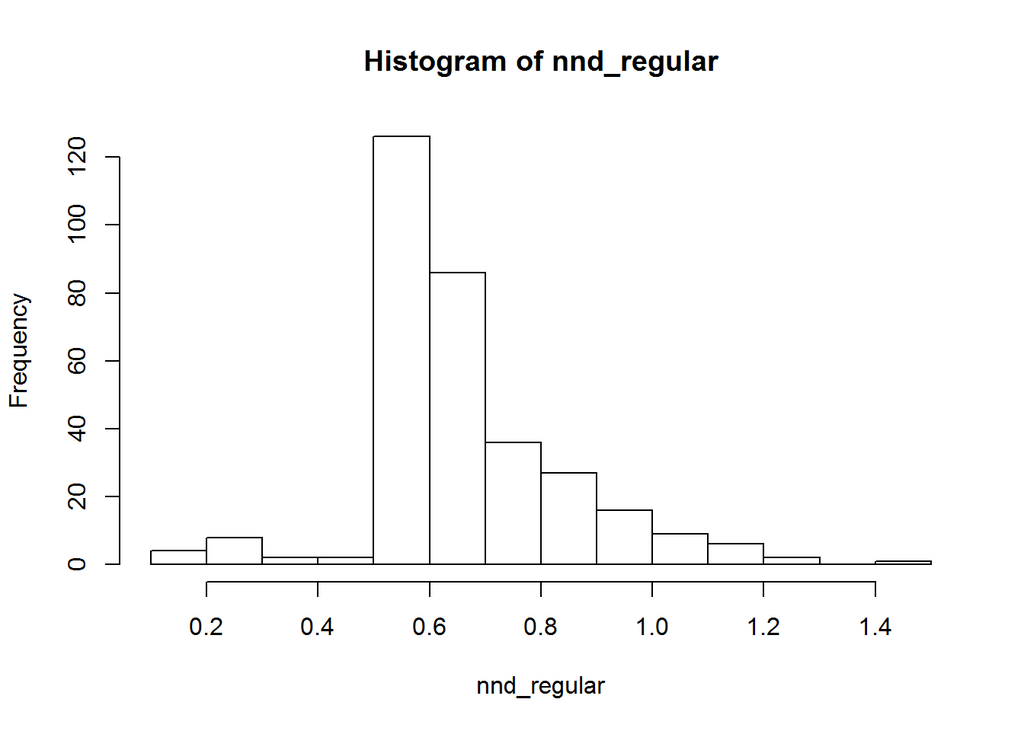

```r
# Repeat for regular point data
nnd_regular <- nndist(p_regular)
hist(nnd_regular)
```

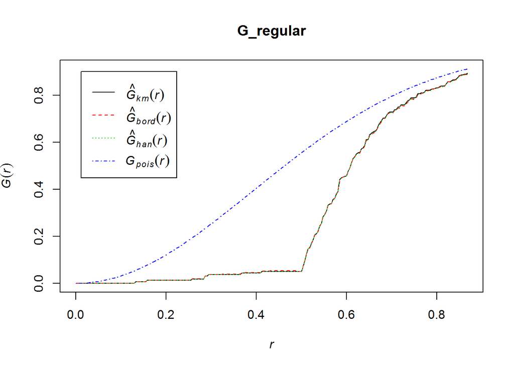

```r
G_regular <- Gest(p_regular)
plot(G_regular)
```

```r
# A number of other functions of point patterns have been developed
# They are conventionally denoted by various capital letters, including F, H, J, K and L

# The K-function is defined as the expected number of points within a distance of a point of the process, scaled by the intensity
# Like G, this can be computed theoretically for a uniform Poisson process and is K(r) = pi * r ^ 2 - the area of a circle of that radius
# Deviation from pi * r ^ 2 can indicate clustering or point inhibition
# Computational estimates of K(r) are done using the Kest() function.

# As with G calculations, K-function calculations also need edge corrections
# The default edge correction in spatstat is generally the best, but can be slow, so we'll use the "border" correction for speed here

# Uncertainties on K-function estimates can be assessed by randomly sampling points from a uniform Poisson process in the area and computing the K-function of the simulated data
# Repeat this process 99 times, and take the minimum and maximum value of K over each of the distance values
# This gives an envelope - if the K-function from the data goes above the top of the envelope then we have evidence for clustering
# If the K-function goes below the envelope then there is evidence for an inhibitory process causing points to be spaced out
# Envelopes can be computed using the envelope() function

# The plot method for estimates of K uses a formula system where a dot on the left of a formula refers to K®
# So the default plot uses . ~ r
# You can compare the estimate of K to a Poisson process by plotting . - pi * r ^ 2 ~ r
# If the data was generated by a Poisson process, then the line should be close to zero for all values of r

# Point patterns are pre-defined
p_poisson
```

```
## Planar point pattern: 481 points
## window: polygonal boundary
## enclosing rectangle: [-10, 10] x [-10, 10] units
```

```r
p_cluster
```

```
## Planar point pattern: 332 points
## window: polygonal boundary
## enclosing rectangle: [-10, 10] x [-10, 10] units
```

```r
p_regular
```

```
## Planar point pattern: 325 points
## window: polygonal boundary
## enclosing rectangle: [-10, 10] x [-10, 10] units
```

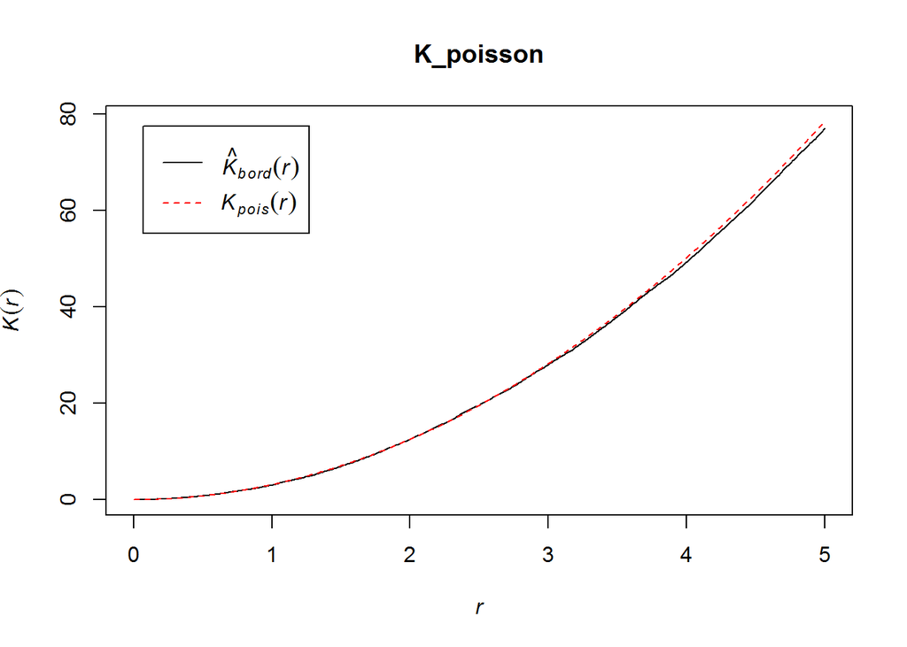

```r
# Estimate the K-function for the Poisson points
K_poisson <- Kest(p_poisson, correction = "border")

# The default plot shows quadratic growth
plot(K_poisson, . ~ r)
```

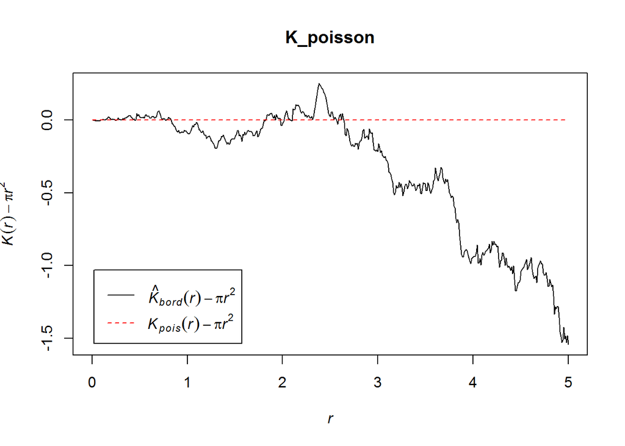

```r
# Subtract pi * r ^ 2 from the Y-axis and plot
plot(K_poisson, . - pi * r**2 ~ r)
```

```r
# Compute envelopes of K under random locations
K_cluster_env <- envelope(p_cluster, Kest, correction = "border")
```

[output not shown]

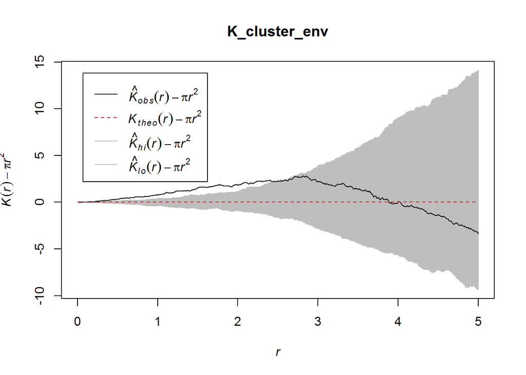

```r
# Insert the full formula to plot K minus pi * r^2
plot(K_cluster_env, . - pi * r^2 ~ r)
```

```r
# Repeat for regular data
K_regular_env <- envelope(p_regular, Kest, correction = "border")
```

[output not shown]

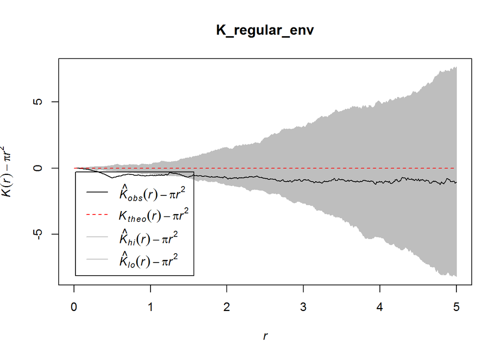

```r
plot(K_regular_env, . - pi * r^2 ~ r)
```

Chapter 2 - Point Pattern Analysis

Bivariate point problems:

- People tend to clump together in cities in neighborhoods, so “things people do/cause” (accidents, crime, etc.) are likely to be clumped even in the absence of differential rates
- The bivariate point pattern is the solution - look at both where things do happen and also where they do not happen (e.g., with disease, looking at prevalence rate rather than total patient counts by area)
  - Can run either a bivariate nearest neighbors or a bivariate K-function
  - The null hypothesis is usually one of uniform rates, which is to say that there is no clustering of incidents and controls
- Kernel smoothing can help with plotting the rates - replace each event with a kernel, and assign every point the sum of all kernels
  - Need to pick the shape and bandwidth of the kernel
  - The spatstat package has some reasonable defaults, and these can be over-ridden if desired

Spatial segregation:

- The null hypothesis is typically that rates are constant wherever you go within the window (though volumes might clump)
  - The spseg() function estimates a bandwidth for the kernel function
  - This is then used for creating the rates by point, which can be plotted
- Monte Carlo simulation can be used to permute the events, keeping event locations and relative ratio of events within the window constant
  - Can then find from simulation the 95% CI for event rate, and identify outliers on the graph
  - Can use plotmc() somehow to get the confidence intervals overlayed on the original plot, although it does not always work directly with ppp

Space-time data:

- Can have a purely temporal process, which also includes a “window” (start and end time)
  - Each coordinate will now have a t coordinate, so frequently (x, y, t)
  - The t needs to be numeric, so make a switch if it was included as a Character or Date or POSIXct or the like
  - Can plot in several ways, though typically the time is shown as a histogram while the (x, y) are plotted as in previous chapters
- The rggobi package can provide linked plot, where you brush point by time and see various highlighting associated to the selection

Space-time clustering:

- Often, there is interest in testing a hypothesis of space-time independence
- The Space-Time K Function typically has time on the y-axis and “spatial distance” on the x-axis
  - Basically, there is a cylinder of space time, for points within distance d and also within time t of each other
  - Assuming independence, then Ks(s) * Kt(t) = Kst(s, t)
  - Can define a test statistic D(s, t) = Kst(s, t) - Ks(s) * Kt(t)
- The test consists of Monte Carlo with permuted event times - same distances, same times, but not interaction effect
  - Compare the observed test statistic D with the Monte Carlo null simulations
  - Can run stmctest(myPoints, myTimes, shapeWindow, timeWindow, dIntervals, tIntervals, nSim)

Example code includes:

```r
# The dataset we shall use for this example consists of crimes in a 4km radius of the center of Preston, a town in north-west England
# We want to look for hotspots of violent crime in the area

# A ppp object called preston_crime has been constructed
# This is a marked point process, where each point is marked as either a "Violent Crime" or a "Non-violent crime"
# The marks for each point can be retrieved using the marks() function
# The window is a 4km circle centered on the town center

# A map image of the town from OpenStreetMap has also been loaded, called preston_osm

preston_crime <- readRDS("./RInputFiles/pcrime-spatstat.RDS")
preston_osm <- readRDS("./RInputFiles/osm_preston_gray.RDS")

# Get some summary information on the dataset
summary(preston_crime)
```

```
## Marked planar point pattern:  2036 points
## Average intensity 4.053214e-05 points per square unit
##
## Coordinates are given to 2 decimal places
## i.e. rounded to the nearest multiple of 0.01 units
##
## Multitype:
##                   frequency proportion    intensity
## Non-violent crime      1812  0.8899804 3.607281e-05
## Violent crime           224  0.1100196 4.459332e-06
##
## Window: polygonal boundary
## single connected closed polygon with 99 vertices
## enclosing rectangle: [349773, 357771] x [425706.5, 433705.5] units
## Window area = 50231700 square units
## Fraction of frame area: 0.785
```

```r
# Get a table of marks
table(marks(preston_crime))
```

```
##
## Non-violent crime     Violent crime
##              1812               224
```

[figure not shown]

```r
# Define a function to create a map
preston_map <- function(cols = c("green","red"), cex = c(1, 1), pch = c(1, 1)) {
  raster::plotRGB(preston_osm) # from the raster package
  plot(preston_crime, cols = cols, pch = pch, cex = cex, add = TRUE, show.window = TRUE)
}

# Draw the map with colors, sizes and plot character
preston_map(
  cols = c("black", "red"),
  cex = c(0.5, 1),
  pch = 19
)
```

```r
# One method of computing a smooth intensity surface from a set of points is to use kernel smoothing
# Imagine replacing each point with a dot of ink on absorbent paper
# Each individual ink drop spreads out into a patch with a dark center, and multiple drops add together and make the paper even darker
# With the right amount of ink in each drop, and with paper of the right absorbency, you can create a fair impression of the density of the original points
# In kernel smoothing jargon, this means computing a bandwidth and using a particular kernel function

# To get a smooth map of violent crimes proportion, we can estimate the intensity surface for violent and non-violent crimes, and take the ratio
# To do this with the density() function in spatstat, we have to split the points according to the two values of the marks and then compute the ratio of the violent crime surface to the total
# The function has sensible defaults for the kernel function and bandwidth to guarantee something that looks at least plausible

# preston_crime has been pre-defined
preston_crime
```

```
## Marked planar point pattern: 2036 points
## Multitype, with levels = Non-violent crime, Violent crime
## window: polygonal boundary
## enclosing rectangle: [349773, 357771] x [425706.5, 433705.5] units
```

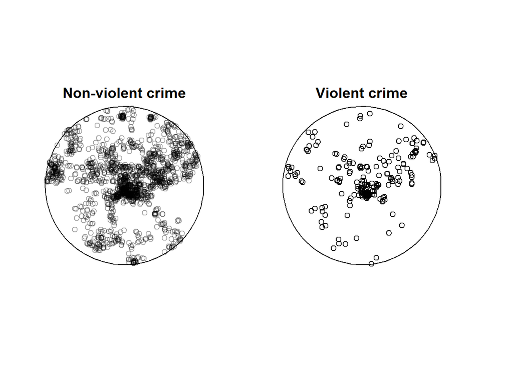

```r
# Use the split function to show the two point patterns
crime_splits <- split(preston_crime)

# Plot the split crime
plot(crime_splits)
```

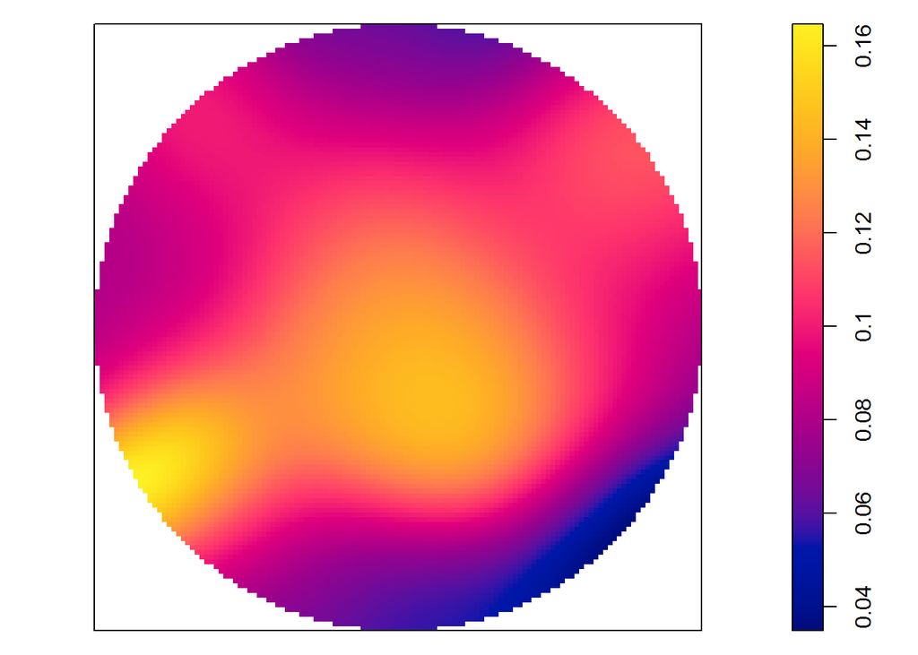

```r
# Compute the densities of both sets of points
crime_densities <- density(crime_splits)

# Calc the violent density divided by the sum of both
frac_violent_crime_density <- crime_densities[[2]] /
  (crime_densities[[1]] + crime_densities[[2]])

# Plot the density of the fraction of violent crime
plot(frac_violent_crime_density)
```

```r
# We can get a more principled measure of the violent crime ratio using a spatial segregation model
# The spatialkernel package implements the theory of spatial segregation

# The first step is to compute the optimal bandwidth for kernel smoothing under the segregation model
# A small bandwidth would result in a density that is mostly zero, with spikes at the event locations
# A large bandwidth would flatten out any structure in the events, resulting in a large "blob" across the whole window
# Somewhere between these extremes is a bandwidth that best represents an underlying density for the process

# spseg() will scan over a range of bandwidths and compute a test statistic using a cross-validation method
# The bandwidth that maximizes this test statistic is the one to use
# The returned value from spseg() in this case is a list, with h and cv elements giving the values of the statistic over the input h values
# The spatialkernel package supplies a plotcv function to show how the test value varies
# The hcv element has the value of the best bandwidth

# spatstat is loaded and the preston_crime object is read in

# Scan from 500m to 1000m in steps of 50m
bw_choice <- spatialkernel::spseg(
    preston_crime,
    h = seq(500, 1000, by = 50),
    opt = 1)
```

```
##
## Calculating cross-validated likelihood function
```

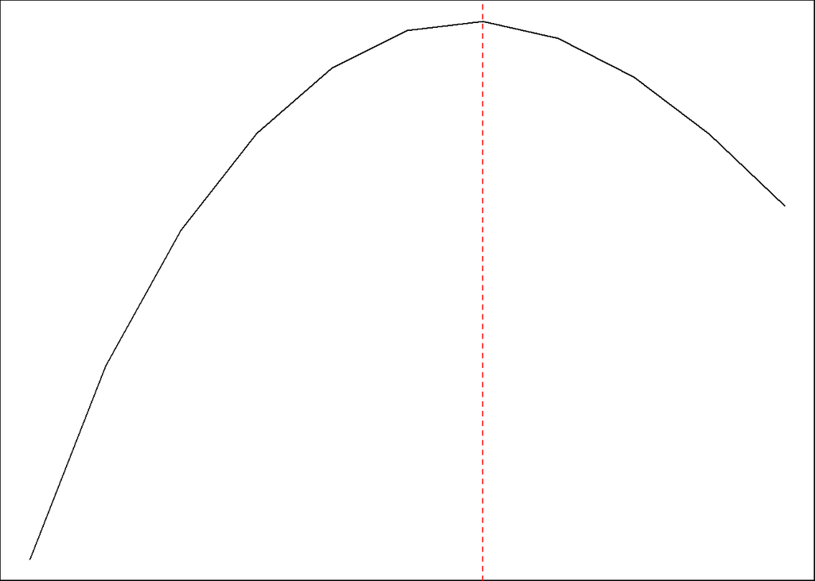

```r
# Plot the results and highlight the best bandwidth
spatialkernel::plotcv(bw_choice)
abline(v = bw_choice$hcv, lty = 2, col = "red")
```

```r
# Print the best bandwidth
print(bw_choice$hcv)
```

```
## [1] 800
```

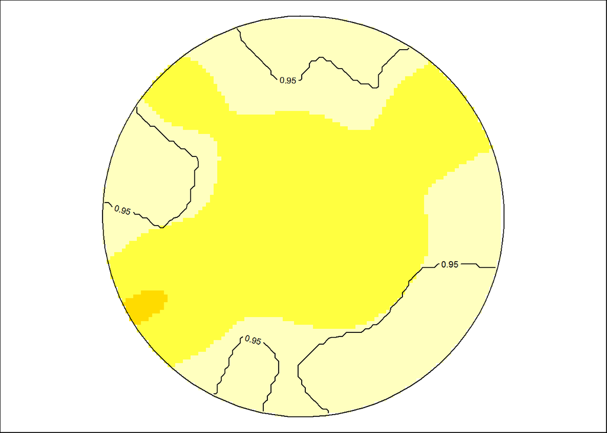

```r
# The second step is to compute the probabilities for violent and non-violent crimes as a smooth surface, as well as the p-values for a point-wise test of segregation
# This is done by calling spseg() with opt = 3 and a fixed bandwidth parameter h

# Normally you would run this process for at least 100 simulations, but that will take too long to run here
# Instead, run for only 10 simulations
# Then you can use a pre-loaded object seg which is the output from a 1000 simulation run that took about 20 minutes to complete

# Set the correct bandwidth and run for 10 simulations only
seg10 <- spatialkernel::spseg(
    pts = preston_crime,
    h = bw_choice$hcv,
    opt = 3,
    ntest = 10,
    proc = FALSE)

# Plot the segregation map for violent crime
spatialkernel::plotmc(seg10, "Violent crime")
```

```r
# Plot seg, the result of running 1000 simulations (not included here)
# spatialkernel::plotmc(seg, "Violent crime")


# With a base map and some image and contour functions we can display both the probabilities and the significance tests over the area with more control than the plotmc() function.

# The seg object is a list with several components
# The X and Y coordinates of the grid are stored in the $gridx and $gridy elements
# The probabilities of each class of data (violent or non-violent crime) are in a matrix element $p with a column for each class
# The p-value of the significance test is in a similar matrix element called $stpvalue
# Rearranging columns of these matrices into a grid of values can be done with R's matrix() function
# From there you can construct list objects with a vector $x of X-coordinates, $y of Y-coordinates, and $z as the matrix
# You can then feed this to image() or contour() for visualization

# This process may seem complex, but remember that with R you can always write functions to perform complex tasks and those you may repeat often
# For example, to help with the mapping in this exercise you will create a function that builds a map from four different items

# The seg object from 1000 simulations is loaded, as well as the preston_crime points and the preston_osm map image
# Inspect the structure of the spatial segregation object
# str(seg)

# Get the number of columns in the data so we can rearrange to a grid
# ncol <- length(seg$gridx)

# Rearrange the probability column into a grid
# prob_violent <- list(x = seg$gridx,
#                      y = seg$gridy,
#                      z = matrix(seg$p[, "Violent crime"],
#                                 ncol = ncol))
# image(prob_violent)

# Rearrange the p-values, but choose a p-value threshold
# p_value <- list(x = seg$gridx,
#                 y = seg$gridy,
#                 z = matrix(seg$stpvalue[, "Violent crime"] < 0.05,
#                            ncol = ncol))
# image(p_value)

# Create a mapping function
# segmap <- function(prob_list, pv_list, low, high){
#
#   # background map
#   plotRGB(preston_osm)
#
#   # p-value areas
#   image(pv_list,
#         col = c("#00000000", "#FF808080"), add = TRUE)
#
#   # probability contours
#   contour(prob_list,
#           levels = c(low, high),
#           col = c("#206020", "red"),
#           labels = c("Low", "High"),
#           add = TRUE)
#
#   # boundary window
#   plot(Window(preston_crime), add = TRUE)
# }
#
# # Map the probability and p-value
# segmap(prob_violent, p_value, 0.05, 0.15)


# The sasquatch, or "bigfoot", is a large ape-like creature reported to live in North American forests
# The Bigfoot Field Researchers Organization maintains a database of sightings and allows its use for teaching and research
# A cleaned subset of data in north-west USA has been created as the ppp object sasq and is loaded for you to explore the space-time pattern of sightings in the area

# Get a quick summary of the dataset
sasq <- readRDS("./RInputFiles/sasquatch.RDS")
summary(sasq)
```

```
## Marked planar point pattern:  423 points
## Average intensity 2.097156e-09 points per square unit
##
## *Pattern contains duplicated points*
##
## Coordinates are given to 1 decimal place
## i.e. rounded to the nearest multiple of 0.1 units
##
## Mark variables: date, year, month
## Summary:
##       date                 year         month
##  Min.   :1990-05-03   Y2004  : 41   Sep    : 59
##  1st Qu.:2000-04-30   Y2000  : 36   Oct    : 56
##  Median :2003-11-05   Y2002  : 30   Aug    : 54
##  Mean   :2003-08-11   Y2005  : 30   Jul    : 50
##  3rd Qu.:2007-11-02   Y2001  : 26   Nov    : 43
##  Max.   :2016-04-05   Y2008  : 26   Jun    : 41
##                       (Other):234   (Other):120
##
## Window: polygonal boundary
## single connected closed polygon with 64 vertices
## enclosing rectangle: [368187.8, 764535.6] x [4644873, 5434933] units
## Window area = 2.01702e+11 square units
## Fraction of frame area: 0.644
```

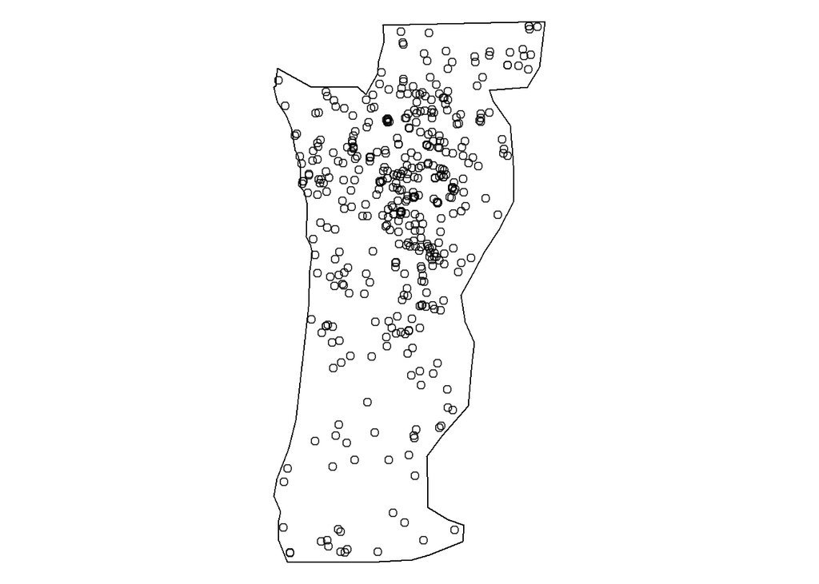

```r
# Plot unmarked points
plot(unmark(sasq))
```

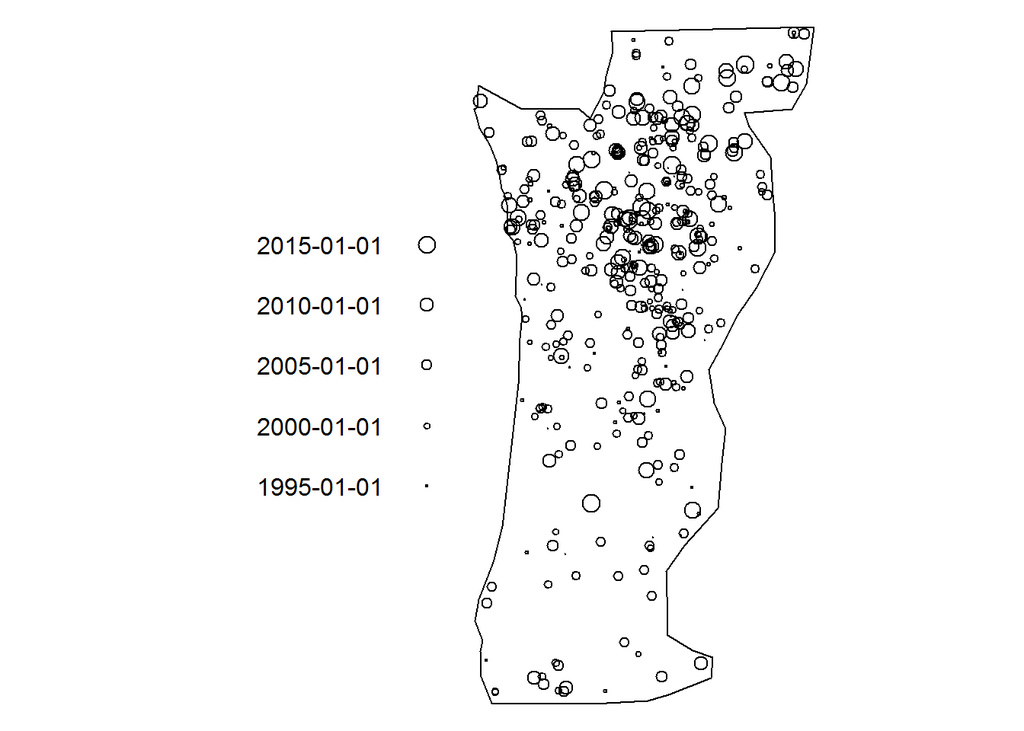

```r
# Plot the points using a circle sized by date
plot(sasq, which.marks = "date")
```

```r
# Show the available marks
names(marks(sasq))
```

```
## [1] "date"  "year"  "month"
```

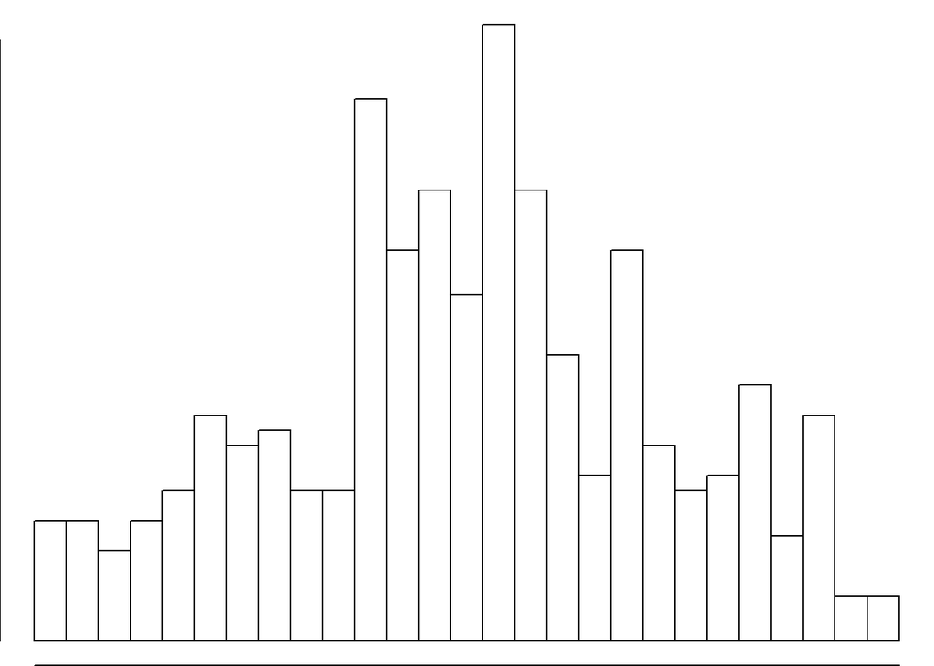

```r
# Histogram the dates of the sightings, grouped by year
hist(marks(sasq)$date, "years", freq = TRUE)
```

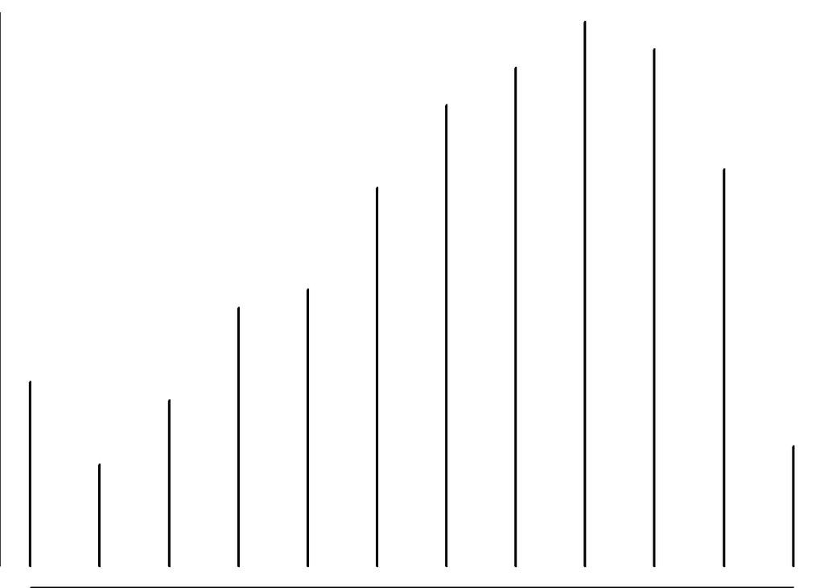

```r
# Plot and tabulate the calendar month of all the sightings
plot(table(marks(sasq)$month))
```

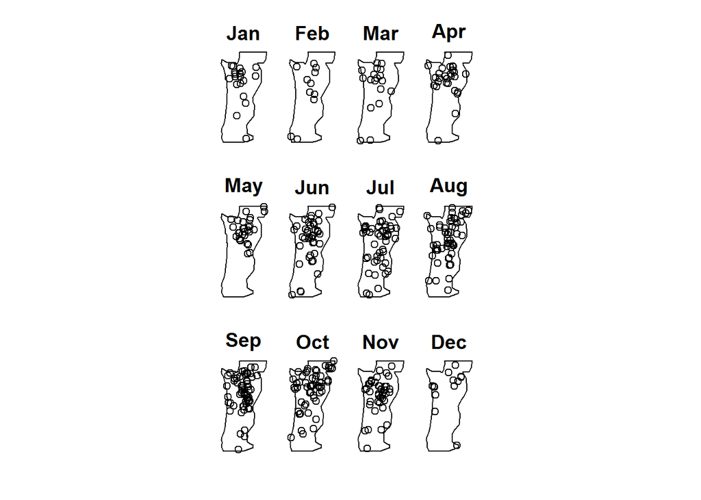

```r
# Split on the month mark
sasq_by_month <- split(sasq, "month", un = TRUE)

# Plot monthly maps
plot(sasq_by_month)
```

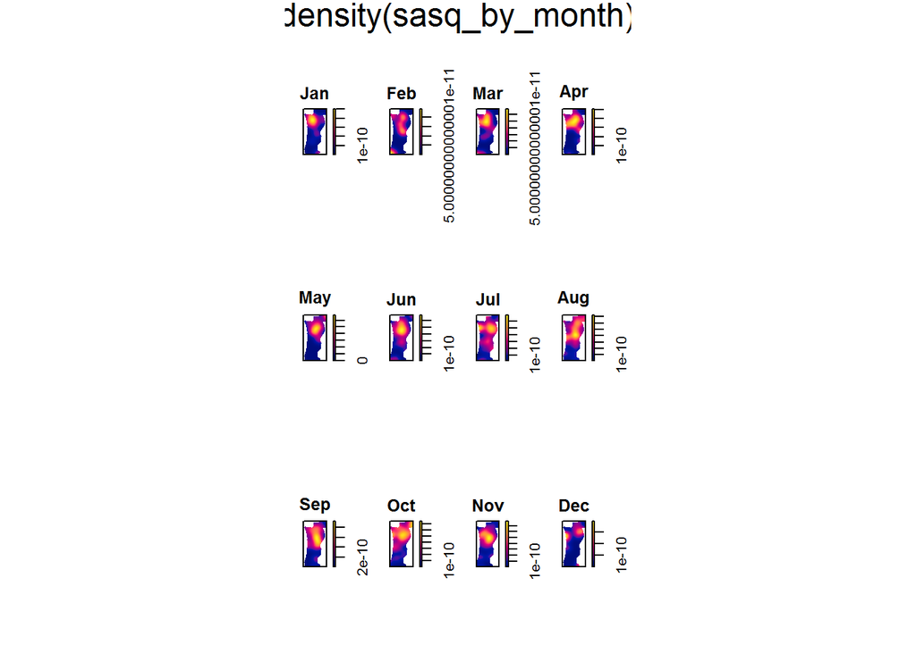

```r
# Plot smoothed versions of the above split maps
plot(density(sasq_by_month))
```

```r
# To do a space-time clustering test with stmctest() from the splancs package, you first need to convert parts of your ppp object
# Functions in splancs tend to use matrix data instead of data frames.
# To run stmctest() you need to set up
# event locations
# event times
# region polygon
# time limits
# the time and space ranges for analysis

# The sasq object is loaded and the spatstat and splancs packages are ready for use
# Get a matrix of event coordinates
sasq_xy <- as.matrix(spatstat::coords(sasq))

# Check the matrix has two columns
dim(sasq_xy)
```

```
## [1] 423   2
```

```r
# Get a vector of event times
sasq_t <- marks(sasq)$date

# Extract a two-column matrix from the ppp object
sasq_poly <- as.matrix(as.data.frame(Window(sasq)))
dim(sasq_poly)
```

```
## [1] 64  2
```

```r
# Set the time limit to 1 day before and 1 day after the range of times
tlimits <- range(sasq_t) + c(-1, 1)

# Scan over 400m intervals from 100m to 20km
s <- seq(100, 20000, by = 400)

# Scan over 14 day intervals from one week to 31 weeks
tm <- seq(7, 217, by = 14)


# Everything is now ready for you to run the space-time clustering test function
# You can then plot the results and compute a p-value for rejecting the null hypothesis of no space-time clustering

# Any space-time clustering in a data set will be removed if you randomly rearrange the dates of the data points
# The stmctest() function computes a clustering test statistic for your data based on the space-time K-function - how many points are within a spatial and temporal window of a point of the data
# It then does a number of random rearrangements of the dates among the points and computes the clustering statistic
# After doing this a large number of times, you can compare the test statistic for your data with the values from the random data
# If the test statistic for your data is sufficiently large or small, you can reject the null hypothesis of no space-time clustering

# The output from stmctest() is a list with a single t0 which is the test statistic for your data, and a vector of t from the simulations
# By converting to data frame you can feed this to ggplot functions

# Because the window area is a large number of square meters, and we have about 400 events, the numerical value of the intensity is a very small number
# This makes values of the various K-functions very large numbers, since they are proportional to the inverse of the intensity
# Don't worry if you see 10^10 or higher

# The p-value of a Monte-Carlo test like this is just the proportion of test statistics that are larger than the value from the data
# You can compute this from the t and t0 elements of the output

# All the objects from the previous exercise are loaded.

# Run 999 simulations
sasq_mc <- splancs::stmctest(sasq_xy, sasq_t, sasq_poly, tlimits, s, tm, nsim = 999, quiet = TRUE)
names(sasq_mc)
```

```
## [1] "t0" "t"
```

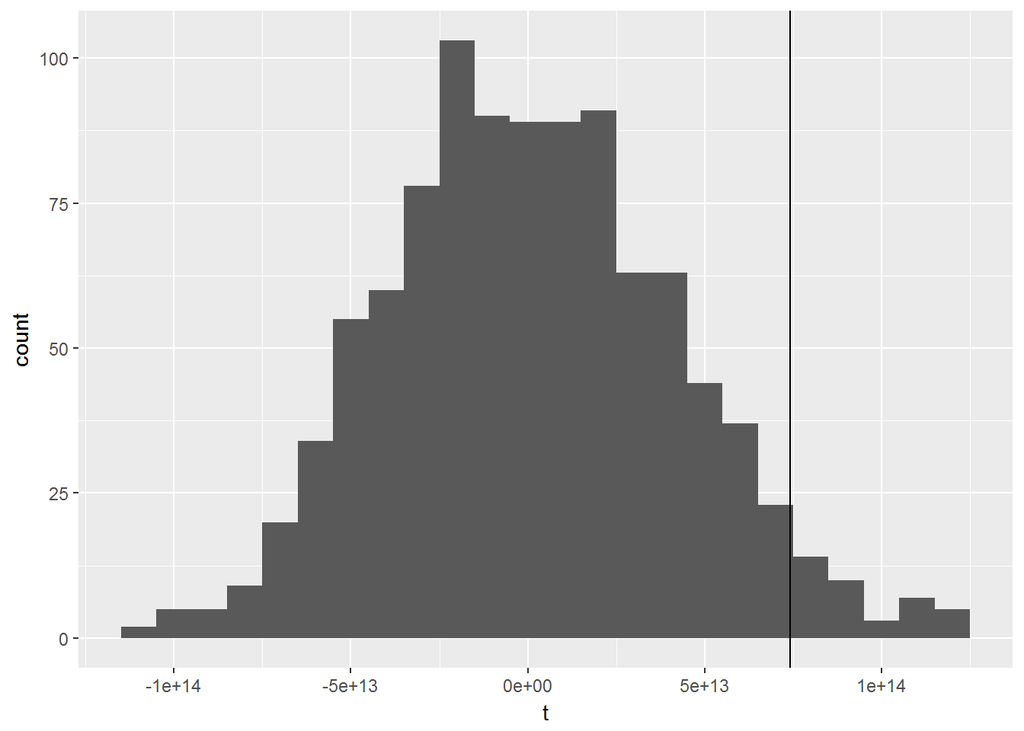

```r
# Histogram the simulated statistics and add a line at the data value
ggplot(data.frame(sasq_mc), aes(x = t)) +
  geom_histogram(binwidth = 1e13) +
  geom_vline(aes(xintercept = t0))
```

```r
# Compute the p-value as the proportion of tests greater than the data
sum(sasq_mc$t > sasq_mc$t0) / 1000
```

```
## [1] 0.04
```

Chapter 3 - Areal Statistics

Areal statistics:

- Areal statistics is the idea of point data being aggregated in to a region (for example, for confidentiality reasons)
  - Boundaries are typically note created in a manner that supports good statistical analysis
- The cartogram is one solution to areal statistics - the cartogram makes the area proportional to a unit of interest (e.g., population)
- The simplest hypothesis is that data are spatially random, which is to say that each region is indepenent of all the other regions
  - The alternative hypothesis is that “neighbors” tend to be more similar than random regions
  - Can run packages to get the neighbors for each region, frequently defined similar to neighbors for a graph (network)
  - Can also convert the list resulting from the neighbors package to an adjacency matrix of 1/0 for who is neighbors
- The Moran I statistic is a test statistic that can be used to assess similarities or differences among neighbors
  - Large positive values of I mean that neighbors tend to be more similar
  - Large negative values of I mean that neighbors tend to be more dissimilar
  - Near-zero values of I mean that neighbors tend to be no more or less similar than any random regions
  - Monte Carlo tests by permuting regional values can build a null distribution

Spatial health data:

- Population health data is frequently available open-source, and often comes in standard forms
  - There is sometimes a challenge in getting the proper rates since the denominator should be “at risk” and not “total population”
  - Incidence Rate is the Number of Cases divided by Population at Risk (typically between 0 and 1)
  - Common to standardize incidence rate as Incidence-Rate-Local / Incidence-Rate-Global, known as SMR (standardized morbidity ratio)
  - The expected number of cases in a region would be Incidence-Rate-Global * Regional-AtRisk-Population (can also be converted to SMR)
- Can run hypothesis tests and confidence intervals on the SMR
  - Can also shade maps based on SMR values (e.g., red for SMR > 2 with 99%+ probability)

Generalized linear models in space:

- Count data are naturally modeled by the Poisson distribution where Y ~ Poisson(e ** (X %*% Beta))
- When applying GLM to spatial data, can have a map of residuals
  - The residuals should be “uncorrelated” and look random
  - If the residuals are “correlated”, then inferences about the parameter estimates are very possibly mistaken
  - There are techniques for dealing with spatial correlations of the residuals

Correlation in spatial GLM:

- Check whether the residuals can be explained by another known factor - add them to the model as needed
- An additional approach is to explcitly add a spatial term S(x, y) to the model
  - The conditional autocorrelation model says that any given region should have mean equal to the average of its neighbors, with variance to be fitted
  - The “car” model stands for “conditionally autocorrelated regression”
- Bayesian statistics are frequently used, basically, what are the likelihoods for the parameter given the observed data?
  - The credible interval is the Bayesian equivalent for confidence interval

Example code includes:

```r
library(cartogram)
library(rgeos)
library(spdep)
library(epitools)
library(R2BayesX)
```

```r
# In 2016 the UK held a public vote on whether to remain in the European Union
# The results of the referendum, where people voted either "Remain" or "Leave", are available online
# The data set london_ref contains the results for the 32 boroughs of London, and includes the number and percentage of votes in each category as well as the count of spoilt votes, the population size and the electorate size

# The london_ref object is a SpatialPolygonsDataFrame, a special kind of data frame where each row also has the shape of the borough
# It behaves like a data frame in many respects, but can also be used to plot a choropleth, or shaded polygon, map

# You should start with some simple data exploration and mapping. The following variables will be useful:
# NAME : the name of the borough.
# Electorate : the total number of people who can vote.
# Remain, Leave : the number of votes for "Remain" or "Leave".
# Pct_Remain, Pct_Leave : the percentage of votes for each sid

# spplot() from the raster package provides a convenient way to draw a shaded map of regions

# See what information we have for each borough
london_ref <- readRDS("./RInputFiles/london_eu.RDS")
summary(london_ref)
```

```
## Object of class SpatialPolygonsDataFrame
## Coordinates:
##        min      max
## x 503574.2 561956.7
## y 155850.8 200933.6
## Is projected: TRUE
## proj4string :
## [+proj=tmerc +lat_0=49 +lon_0=-2 +k=0.9996012717 +x_0=400000
## +y_0=-100000 +datum=OSGB36 +units=m +no_defs +ellps=airy
## +towgs84=446.448,-125.157,542.060,0.1502,0.2470,0.8421,-20.4894]
## Data attributes:
##      NAME             TOTAL_POP        Electorate       Votes_Cast
##  Length:32          Min.   :157711   Min.   : 83042   Min.   : 54801
##  Class :character   1st Qu.:237717   1st Qu.:143458   1st Qu.:104079
##  Mode  :character   Median :272017   Median :168394   Median :116280
##                     Mean   :270780   Mean   :169337   Mean   :118025
##                     3rd Qu.:316911   3rd Qu.:196285   3rd Qu.:134142
##                     Max.   :379691   Max.   :245349   Max.   :182570
##      Remain           Leave       Rejected_Ballots   Pct_Remain
##  Min.   : 27750   Min.   :17138   Min.   : 60.0    Min.   :30.34
##  1st Qu.: 55973   1st Qu.:32138   1st Qu.:105.0    1st Qu.:53.69
##  Median : 70254   Median :45263   Median :138.0    Median :61.01
##  Mean   : 70631   Mean   :47255   Mean   :139.0    Mean   :60.46
##  3rd Qu.: 84287   3rd Qu.:59018   3rd Qu.:164.2    3rd Qu.:69.90
##  Max.   :118463   Max.   :96885   Max.   :267.0    Max.   :78.62
##    Pct_Leave      Pct_Rejected      Assembly
##  Min.   :21.38   Min.   :0.0600   Length:32
##  1st Qu.:30.10   1st Qu.:0.0875   Class :character
##  Median :38.99   Median :0.1100   Mode  :character
##  Mean   :39.54   Mean   :0.1187
##  3rd Qu.:46.31   3rd Qu.:0.1500
##  Max.   :69.66   Max.   :0.2200
```

```r
# Which boroughs voted to "Leave"?
london_ref$NAME[london_ref$Leave > london_ref$Remain]
```

```
## [1] "Sutton"               "Barking and Dagenham" "Bexley"
## [4] "Havering"             "Hillingdon"
```

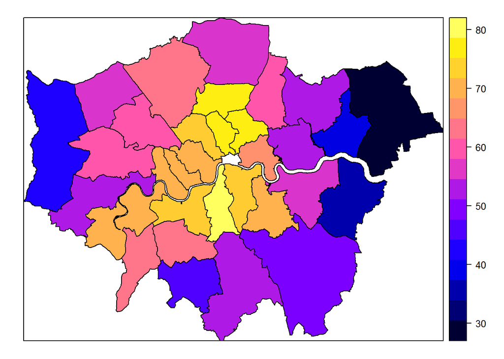

```r
# Plot a map of the percentage that voted "Remain"
sp::spplot(london_ref, zcol = "Pct_Remain")
```

```r
# Large areas, such as cities or countries, are often divided into smaller administrative units, often into zones of approximately equal population
# But the area of those units may vary considerably
# When mapping them, the large areas carry more visual "weight" than small areas, although just as many people live in the small areas.

# One technique for correcting for this is the cartogram
# This is a controlled distortion of the regions, expanding some and contracting others, so that the area of each region is proportional to a desired quantity, such as the population
# The cartogram also tries to maintain the correct geography as much as possible, by keeping regions in roughly the same place relative to each other

# The cartogram package contains functions for creating cartograms
# You give it a spatial data frame and the name of a column, and you get back a similar data frame but with regions distorted so that the region area is proportional to the column value of the regions

# You'll also use the rgeos package for computing the areas of individual regions with the gArea() function

# Use the cartogram and rgeos packages (called at top of routine)
# library(cartogram)
# library(rgeos)

# Make a scatterplot of electorate vs borough area
names(london_ref)
```

```
##  [1] "NAME"             "TOTAL_POP"        "Electorate"
##  [4] "Votes_Cast"       "Remain"           "Leave"
##  [7] "Rejected_Ballots" "Pct_Remain"       "Pct_Leave"
## [10] "Pct_Rejected"     "Assembly"
```

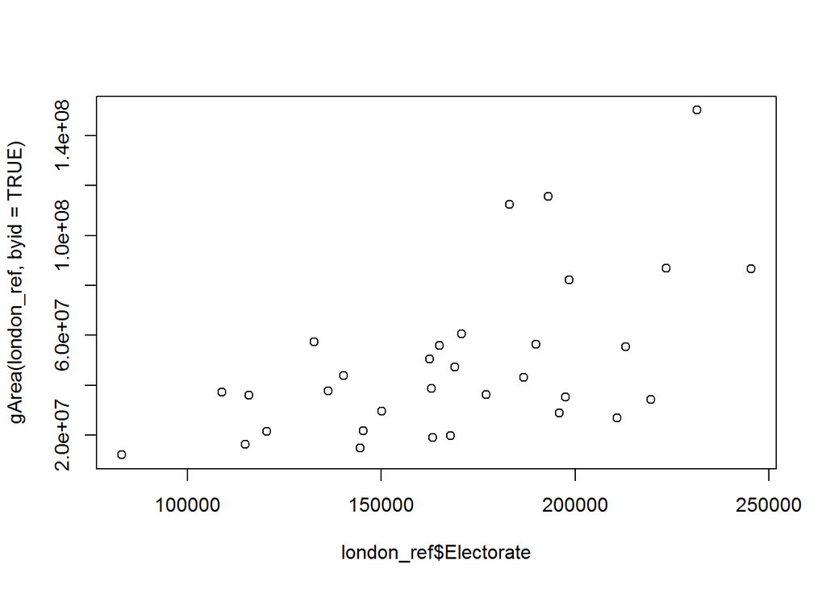

```r
plot(london_ref$Electorate, gArea(london_ref, byid = TRUE))
```

```r
# Make a cartogram, scaling the area to the electorate
carto_ref <- cartogram(london_ref, "Electorate")
```

[output not shown]

[output not shown]

[output not shown]

[output not shown]

[output not shown]

[output not shown]

[output not shown]

[output not shown]

[output not shown]

[output not shown]

[output not shown]

[output not shown]

[output not shown]

[output not shown]

[output not shown]

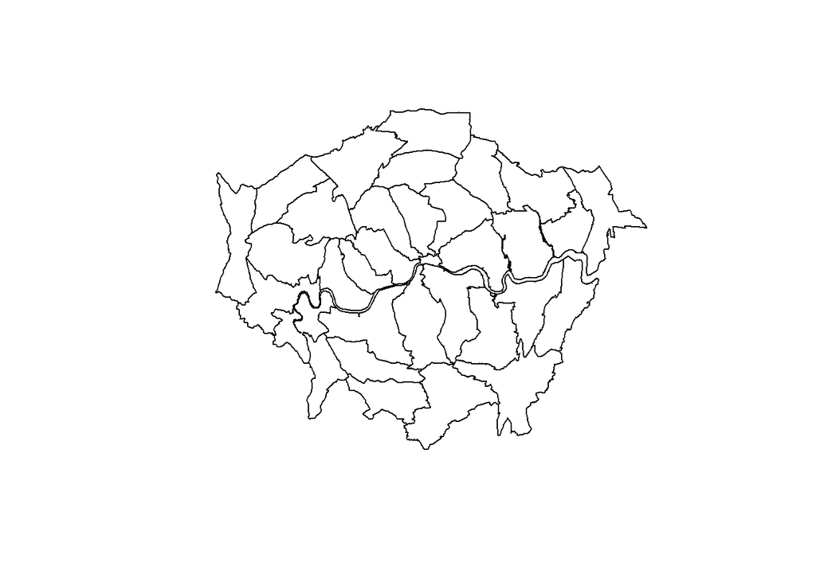

```r
plot(carto_ref)
```

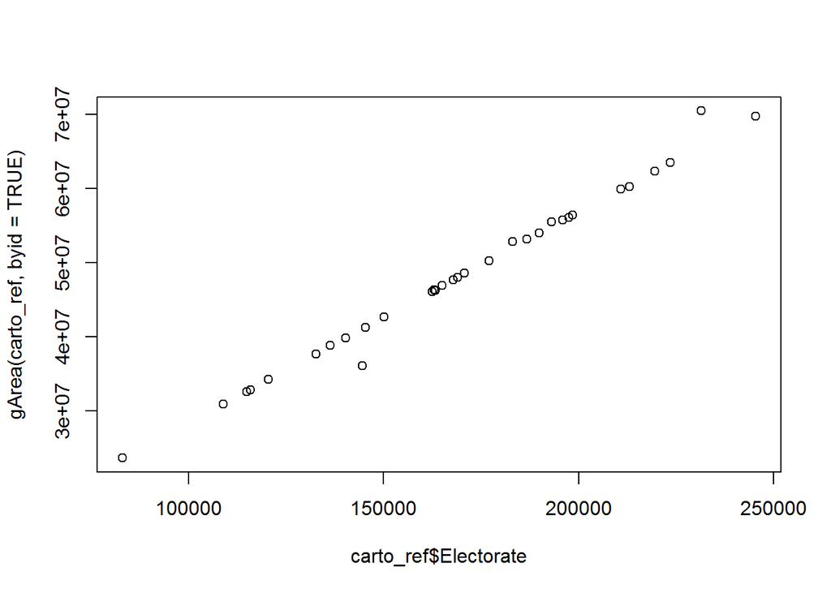

```r
# Check the linearity of the electorate-area plot
plot(carto_ref$Electorate, gArea(carto_ref, byid = TRUE))
```

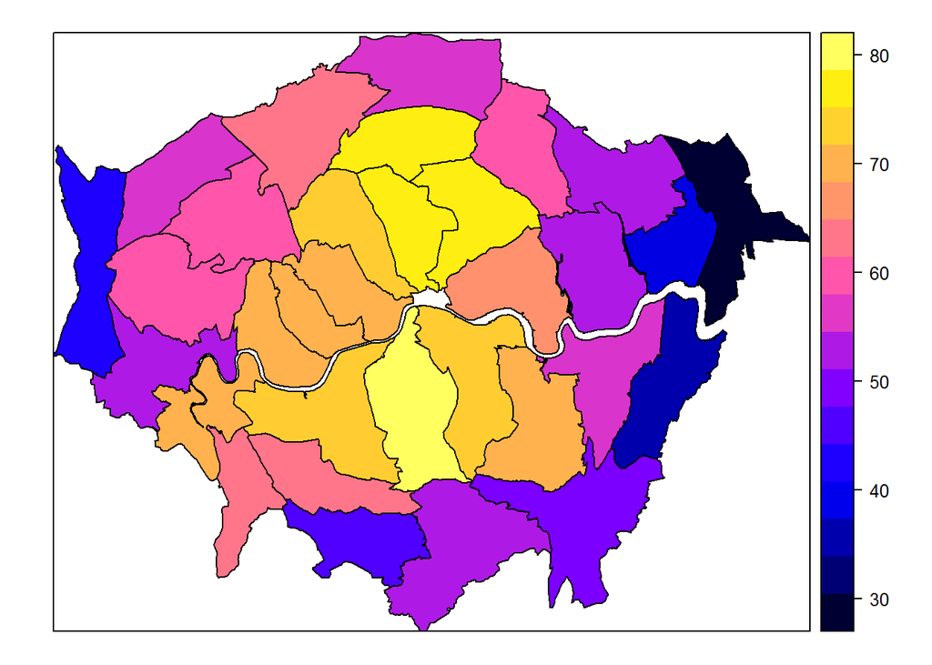

```r
# Make a fairer map of the Remain percentage
sp::spplot(carto_ref, "Pct_Remain")
```